# Day 18 Agent-Based Models - Superbugs 2

## Nov. 17, 2020

[figure not shown]

# Announcements

- **Homework 5** Coming soon. Working with Tensorflow. Will be due 12/4.
- **Projects** Rubric nearly complete and will be posted this week.
  - Due finals week
  - 8-10 minute video presentation + documented notebook on your analysis
  - 3 In-class work periods for the project

# Calendar

## This week

- Today: Day 18 Agent Based Models
- Thursday: Day 19 Perceptron model

## Thanksgiving week

- Tuesday 11/24: Project work day 1
- Thursday 11/26: No class

## Week after Thanksgiving

- Tuesday 12/1: Day 20 Neural Networks 1
- Thursday 12/3: Day 21 Neural Networks 2

## Last week of classes

- Tuesday 12/8: Project work day 2
- Thursday 12/10: Project work day 3

# Today

- You will be given working code for the superbugs program
  - You will need to investigate how it works and how to implement it
- You will come up with scientific questions to investigate with the program
  - Your group will present your scientific question and results at the end of class

**You will have to animate a graph.**

# Animating a graph

- There are many ways to do this, but we can use `IPython.display` to produce and clear output.

We will need to import:

- `from IPython.display import display, clear_output`
- `import matplotlib.pylab as plt`

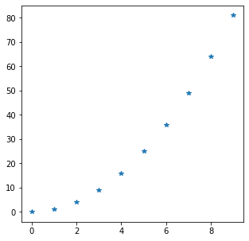

```python
from IPython.display import display, clear_output
import matplotlib.pylab as plt
import numpy as np

fig, ax = plt.subplots(figsize=(5,5))

x = np.arange(10)
y = x**2

plt.plot(x,y,'*')
```

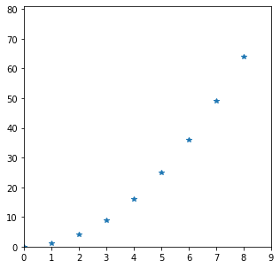

```python
from IPython.display import display, clear_output
import matplotlib.pylab as plt
import numpy as np

fig, ax = plt.subplots(figsize=(5,5))

#### SUPER BUGS ####
x_list=[]
y_list=[]

for x in np.arange(9):

    x_list.append(x)
    y_list.append(x**2)

    plt.plot(x_list, y_list, '*')
    plt.axis([0, 9, 0, 81])
#### SUPER BUGS ####

    ## Stay the same
    clear_output(wait=True) # clears display
    display(fig) # resets display
    fig.clear() # stops overlapping
```

# Questions, Comments, Concerns?